# FINAL REPORT: Breath and Wealth: Predicting County Livability

**Team: Data Minding** - Ayush Panda, Hayley Nguyen, Jose Garcia Rowlands, Trong Gia Hung Nguyen, Trinh Phan  
**Github Repo:** https://github.com/uic-cs418/group-project-data-minding

## **Data Cleaning**

**Datasets:**  
In this project, we have used two main types of datasets: **Air Quality Index (AQI)** and **Income**.

The links to access these datasets are:

- **AQI:** https://aqs.epa.gov/aqsweb/airdata/download_files.html#Daily
- **Income:** https://www.census.gov/data/tables/2024/demo/income-poverty/p60-282.html

**Datasets Description:**  
The AQI datasets from the United States Environment Protection Agency (EPA) provide a wide variety of records. In this study, we chose to use datasets for four main pollutants: **Ozone (O₃), Sulfur Dioxide (SO₂), Carbon Monoxide (CO), and Nitrogen Dioxide (NO₂)**, along with four key meteorological variables: **Wind Speed/Direction, Temperature, Barometric Pressure, and Relative Humidity/Dewpoint**.

These pollutants are common in urban areas and have known health impacts. Meteorological variables were included for their role in shaping how pollutants spread and accumulate over time and space.

```python
# --- Data Handling ---
import pandas as pd
import numpy as np
import os
# --- Data Cleaning & Preprocessing ---
from datetime import datetime
# --- Visualization ---
import matplotlib.pyplot as plt
import seaborn as sns
# --- Machine Learning ---
from sklearn.model_selection import train_test_split
from sklearn.linear_model import LinearRegression
from sklearn.ensemble import RandomForestRegressor
from sklearn.metrics import mean_squared_error, r2_score
from sklearn.preprocessing import StandardScaler
# For classification task or livability labeling
from sklearn.ensemble import RandomForestClassifier
# --- Warnings ---
import warnings
warnings.filterwarnings('ignore')
```

The `combine_datasets_POLLUTANTS` function manages the cleaning and merging of pollutant datasets. Each CSV is first processed with the `clean_pollutant_dataset` helper, which filters by pollutant standard, converts date formats, and removes invalid or duplicate entries.

Cleaned datasets are renamed with pollutant-specific suffixes (e.g., `Arithmetic Mean_ozone`) to avoid column conflicts, then merged using an inner join on shared fields (**State Name**, **County Name**, **Date Local**, **Local Site Name**). The final dataset is sorted by location and date and saved for analysis.

```python
functions.combine_datasets_POLLUTANTS(
    "data/daily_44201_2023.csv",  "data/daily_42401_2023.csv", "data/daily_42101_2023.csv", "data/daily_42602_2023.csv", "data/merged_ALL_POLLUTANTS_2023.csv"
)
functions.combine_datasets_POLLUTANTS(
    "data/daily_44201_2024.csv",  "data/daily_42401_2024.csv", "data/daily_42101_2024.csv", "data/daily_42602_2024.csv", "data/merged_ALL_POLLUTANTS_2024.csv"
)
functions.combine_datasets_METEO("data/daily_PRESS_2023.csv", "data/daily_RH_DP_2023.csv", "data/daily_TEMP_2023.csv", "data/daily_WIND_2023.csv", "data/merged_ALL_METEO_2023.csv")
functions.combine_datasets_METEO("data/daily_PRESS_2024.csv", "data/daily_RH_DP_2024.csv", "data/daily_TEMP_2024.csv", "data/daily_WIND_2024.csv", "data/merged_ALL_METEO_2024.csv")
```

```python
df_POLLUTANT_2023 = pd.read_csv("data/merged_ALL_POLLUTANTS_2023.csv")
df_POLLUTANT_2023.head(3)
```

|  | State Name | County Name | Date Local | Local Site Name | Arithmetic Mean_ozone | 1st Max Value_ozone | 1st Max Hour_ozone | Arithmetic Mean_so2 | 1st Max Value_so2 | 1st Max Hour_so2 | Arithmetic Mean_co | 1st Max Value_co | 1st Max Hour_co | Arithmetic Mean_no2 | 1st Max Value_no2 | 1st Max Hour_no2 |
| --- | --- | --- | --- | --- | --- | --- | --- | --- | --- | --- | --- | --- | --- | --- | --- | --- |
| 0 | Alabama | Jefferson | 2023-01-01 | North Birmingham | 0.031588 | 0.041 | 9 | -0.087500 | 0.0 | 11 | 0.126316 | 0.2 | 19 | 5.2375 | 16.5 | 18 |
| 1 | Alabama | Jefferson | 2023-01-02 | North Birmingham | 0.019824 | 0.023 | 22 | 0.329167 | 0.9 | 8 | 0.137500 | 0.3 | 0 | 4.9750 | 9.6 | 7 |
| 2 | Alabama | Jefferson | 2023-01-03 | North Birmingham | 0.021471 | 0.023 | 22 | 0.000000 | 0.3 | 6 | 0.112500 | 0.2 | 17 | 5.4625 | 9.9 | 17 |

```python
df_METEO_2024 = pd.read_csv("data/merged_ALL_METEO_2024.csv")
df_METEO_2024.head(3)
```

|  | State Name | County Name | Date Local | Local Site Name | Arithmetic Mean_PRESS | 1st Max Value_PRESS | 1st Max Hour_PRESS | Arithmetic Mean_RH_DP | 1st Max Value_RH_DP | 1st Max Hour_RH_DP | Arithmetic Mean_TEMP | 1st Max Value_TEMP | 1st Max Hour_TEMP | Arithmetic Mean_WIND_SPEED | 1st Max Value_WIND_SPEED | 1st Max Hour_WIND_SPEED | Arithmetic Mean_WIND_DIRECTION | 1st Max Value_WIND_DIRECTION | 1st Max Hour_WIND_DIRECTION |
| --- | --- | --- | --- | --- | --- | --- | --- | --- | --- | --- | --- | --- | --- | --- | --- | --- | --- | --- | --- |
| 0 | Alabama | Escambia | 2024-01-01 | PCI MET1 | 1012.133333 | 1015.4 | 23 | 73.829167 | 95.1 | 7 | 46.3375 | 58.7 | 13 | 4.225000 | 8.2 | 15 | 277.333333 | 337.0 | 21 |
| 1 | Alabama | Escambia | 2024-01-02 | PCI MET1 | 1013.787500 | 1016.4 | 8 | 71.008333 | 91.2 | 22 | 38.9250 | 54.5 | 15 | 3.187500 | 8.0 | 9 | 107.958333 | 320.0 | 17 |
| 2 | Alabama | Escambia | 2024-01-03 | PCI MET1 | 1008.520833 | 1010.0 | 9 | 83.125000 | 93.3 | 23 | 42.4875 | 47.9 | 13 | 4.779167 | 10.6 | 12 | 97.541667 | 209.0 | 22 |

To ensure consistency, we kept only states and counties that appear in **both** 2023 and 2024 datasets.  
Key steps:

- Identified shared locations across years.
- Removed unmatched records from each dataset.
- Merged all four pollutant datasets and AQI data for both years using inner joins.

This ensured that the final dataset only includes regions with complete data across both years.

```python
functions.combine_all_data("data/merged_ALL_METEO_2023.csv", "data/merged_ALL_POLLUTANTS_2023.csv", "data/daily_aqi_by_county_2023.csv", "data/all_attributes_2023.csv")
functions.combine_all_data("data/merged_ALL_METEO_2024.csv", "data/merged_ALL_POLLUTANTS_2024.csv", "data/daily_aqi_by_county_2024.csv", "data/all_attributes_2024.csv")

commonStates = functions.get_common_states("data/all_attributes_2023.csv", "data/all_attributes_2024.csv")
print("Common states: ", commonStates)

functions.filter_common_states("data/all_attributes_2023.csv", "data/24StateAQI_2023.csv")
functions.filter_common_states("data/all_attributes_2024.csv", "data/24StateAQI_2024.csv")

functions.combine_csv_files("24StateAQI_2023.csv", "24StateAQI_2024.csv", "AQI.csv")
```

[output not shown]

### Merging AQI and Socioeconomic Data

We loaded AQI data (`FINAL_24StatesAQI.csv`) and 2023 socioeconomic indicators (`ACSDP1Y2023.DP03-Data.csv`) including median income, unemployment rate, and poverty rate.

Key steps:

- Standardized **State** and **County** names for consistency.
- Extracted and cleaned socioeconomic data, removing suffixes like "county", "parish", and "city".
- Merged both datasets on standardized `County Name` and `State Name`.
- Converted relevant columns to numeric and dropped rows with missing values.
- Classified counties into **'Good for Living'** and **'Bad for Living'** based on thresholds for AQI (≤100), income (≥$60,000), unemployment (≤7%), and poverty (≤15%).

The final merged dataset was saved as `Merged_AQI_Income_Poverty_Unemployment_Livability.csv` for further analysis.

```python
merge_aqi_socioeconomic()
# Load the merged dataset
df = pd.read_csv("Merged_AQI_Income_Poverty_Unemployment_Livability.csv")
df.head(3)
```

|  | State Name | County Name | Date | Arithmetic Mean_PRESS | 1st Max Value_PRESS | 1st Max Hour_PRESS | Arithmetic Mean_RH_DP | 1st Max Value_RH_DP | 1st Max Hour_RH_DP | Arithmetic Mean_TEMP | ... | 1st Max Hour_co | Arithmetic Mean_no2 | 1st Max Value_no2 | 1st Max Hour_no2 | AQI | Category | Median_Income | Unemployment_Rate | Poverty_Rate | Livability |
| --- | --- | --- | --- | --- | --- | --- | --- | --- | --- | --- | --- | --- | --- | --- | --- | --- | --- | --- | --- | --- | --- |
| 0 | arizona | maricopa | 2023-01-01 | 967.183333 | 970.3 | 0 | 82.083333 | 90.0 | 16 | 54.041667 | ... | 5 | 9.666667 | 16.0 | 3 | 160 | Unhealthy | 87048.0 | 3.7 | 7.1 | Bad for Living |
| 1 | arizona | maricopa | 2023-01-01 | 967.183333 | 970.3 | 0 | 82.083333 | 90.0 | 16 | 54.041667 | ... | 5 | 7.116667 | 21.4 | 0 | 160 | Unhealthy | 87048.0 | 3.7 | 7.1 | Bad for Living |
| 2 | arizona | maricopa | 2023-01-02 | 973.091667 | 976.5 | 21 | 71.916667 | 94.0 | 5 | 51.833333 | ... | 0 | 10.833333 | 26.0 | 7 | 37 | Good | 87048.0 | 3.7 | 7.1 | Good for Living |

3 rows × 36 columns

## **Exploratory Data Analysis**

### Analysis of Air Quality Data 2023 Dataset

```python
eda_2023()
```

Since the output is too lengthy to display in full, a detailed summary of the findings is provided in the EDA Findings section

### EDA Findings

#### Dataset Overview

- The dataset has **43,501 entries** with **no missing values**, ensuring high reliability for analysis.

#### Descriptive Statistics

| Feature | Mean | Min | Max | Notes |
| --- | --- | --- | --- | --- |
| AQI | 67.8 | 2 | 660 | High variability |
| Temp (°F) | 62.8 | -11 | 106 | Seasonal variation |
| Humidity % | 60.3 | -11.5 | 100 | Some sensor errors |
| SO₂ (ppb) | 0.91 | -1.23 | 700.2 | Extreme pollution spikes |
| CO (ppm) | 0.27 | -0.20 | 1.62 | Generally stable |
| NO₂ (ppb) | 9.92 | -2.25 | 41.0 | Moderate urban pollution |

#### Mode Insights

- **Most Common State:** California
- **Most Common County:** Los Angeles
- **Most Common Date:** July 27, 2023
- **Most Common AQI Category:** Moderate

> The data is primarily focused on California.

#### Variance Summary

- **High Variance:**
  - AQI (**1456.97**) – wide fluctuation in air quality
  - 1st Max Value SO₂ (**1161.32**) – high pollution event spikes
- **Low Variance:**
  - Temperature, Pressure – relatively stable environmental conditions

### **Environment Factor & Socieconomic Factors**

The dataset also has another attribute of Median_Income, Unemployment_Rate, Poverty_Rate, Livability_Label showing how environmental and socioeconomic factors are related

```python
socio_eda()
```

Since the output is too lengthy to display in full, a detailed summary of the findings is provided in the Socioeconomic Summary section

#### Socioeconomic Summary

Out of 43,501 entries, **'Bad for Living'** counties dominate with **34,921 entries**, while **'Good for Living'** has **8,580**.

'Good for Living' counties show significantly better conditions:

> These stats confirm that better air quality and economic conditions align with higher livability.

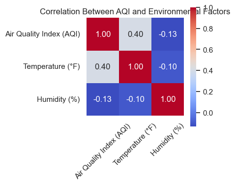

```python
eda_visual1()
```

#### AQI vs Environmental Factors

A heatmap shows:

- **AQI** has a moderate **positive correlation with temperature** (0.40) → hotter days tend to have worse air quality.
- **Humidity** has a slight **negative correlation** with AQI (-0.13) → more humid days may have better air.
- **Temp and humidity** are mildly negatively correlated (-0.10), as expected in typical weather patterns.

## **Visualizations + Additional Visualization**

### **Counties with higher temperatures and higher ozone concentrations experience significantly worse AQI levels compared to counties with lower temperature and ozone levels.**

**Description:**

> These results match real-world situations where **hot weather leads to more ozone** and **pollution builds up when the air doesn’t move much**.

```python
df = pd.read_csv("Merged_AQI_Income_Poverty_Unemployment_Livability.csv")
```

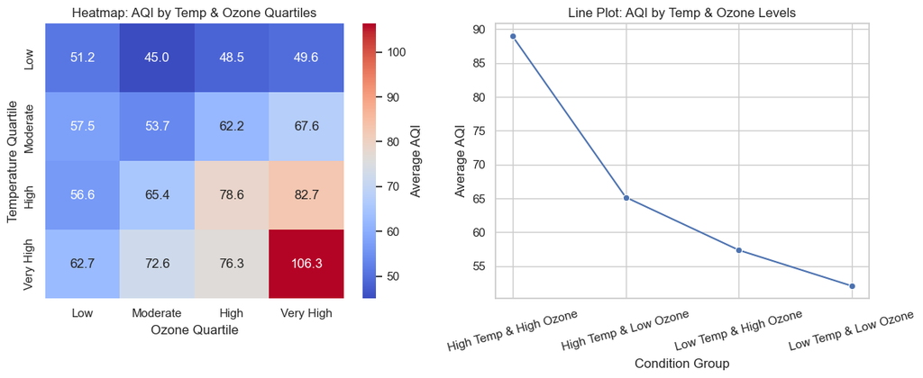

```python
temp_ozone_visual(df)
```

### **AQI levels vary by season, with higher values typically observed during the summer months when temperatures are elevated**

**Description:**  
This visualization was created to explore how AQI levels change across seasons. The results indicate that **summer consistently shows the highest median AQI**, suggesting that warmer weather may be associated with poorer air quality:

- **Summer:** Median AQI is **71**, significantly higher than other seasons.
- **Fall:** Median AQI is **56**, showing a noticeable drop compared to summer.
- **Spring:** Median AQI is **55**, similar to fall, indicating moderate air quality.
- **Winter:** Median AQI is **53**, the lowest among all seasons, suggesting cleaner air in colder months.

These findings may reflect seasonal influences such as **increased ozone formation, stagnant air patterns, or greater emissions from summer activities**, which could degrade air quality during warmer periods.

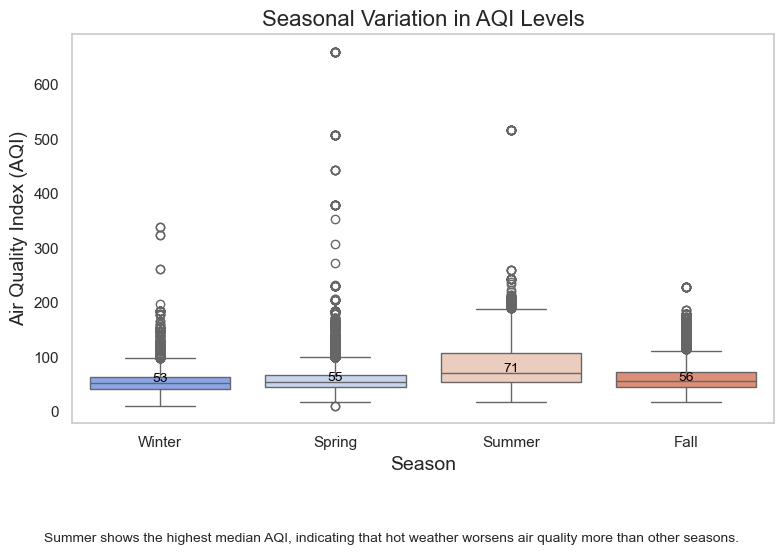

```python
seasonal_aqi_visual(df)
```

### **Counties experiencing both high poverty rates and high unemployment rates suffer from significantly worse air quality (higher AQI) compared to counties with better socioeconomic conditions**

#### Description

This visualization explores how AQI varies by income, poverty, unemployment, and combined socioeconomic stress.

> These trends highlight potential environmental disparities linked to economic and social conditions.

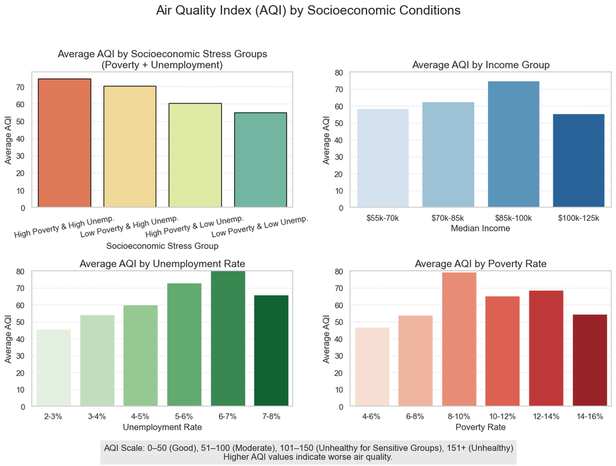

```python
socioeconomic_aqi_visuals(df)
```

### **ML Analaysis**

#### Predicting Air Quality Index (AQI)

We compares two predictive approaches:

1. **Baseline Linear Regression**: Predicts tomorrow’s AQI based on today’s value.
2. **Random Forest Classifier**: Predicts EPA AQI category (e.g., 'Good', 'Moderate') 1–3 days ahead.

We evaluate performance using RMSE, R² for regression, and accuracy metrics for classification.

#### **1. Baseline: Linear Regression on AQI**

This model uses a simple linear regression where the next day’s AQI is predicted from today’s AQI.

- **Technique**: Shift AQI column forward by 1.
- **Model**: Linear regression (minimize squared error).
- **Evaluation**: RMSE and R².

#### **Why It Matters:**

This serves as a benchmark. A high RMSE (~28.6) shows AQI is difficult to predict precisely. It highlights why categorizing AQI may be more practical.

```python
baseline_linear_reg()
```

```
Linear Regression Model:
R2 Score: 0.3928062276324379
RMSE: 28.670776338768757 AQI units
```

#### **2. Random Forest: Predicting EPA Categories**

We classify the AQI category (e.g., Good, Moderate, Unhealthy) based on environmental and pollution data.

##### Features:

- Rolling averages of AQI and pollutants
- Seasonal signals via sine/cosine day-of-year encoding
- Lagged features and future shifted AQI labels

##### Model:

- **RandomForestClassifier** in a pipeline with **StandardScaler**
- Models trained for predicting 1, 2, and 3 days ahead
- **Evaluation**: Exact accuracy and within-one-category accuracy

```python
predict_categories()
```

```
Training category models …
Done.

== Validation split ==
1d  Exact accuracy = 0.583, Within-1 accuracy = 0.975, — predicting category in ONE day
2d  Exact accuracy = 0.558, Within-1 accuracy = 0.973, — predicting category in TWO days
3d  Exact accuracy = 0.539, Within-1 accuracy = 0.971, — predicting category in THREE days

== Test split ==
1d  Exact accuracy = 0.559, Within-1 accuracy = 0.948, — predicting category in ONE day
2d  Exact accuracy = 0.547, Within-1 accuracy = 0.944, — predicting category in TWO days
3d  Exact accuracy = 0.544, Within-1 accuracy = 0.943, — predicting category in THREE days
```

#### **Conclusion**

- Linear regression predicts AQI with moderate accuracy, but struggles with precision (RMSE ~28.6).
- Random forest classifier reliably predicts AQI **categories** and is more useful for public health decisions.

This supports a key insight: **categorical predictions (e.g., EPA labels) are more actionable and robust** than exact AQI predictions.